# LESSON 1: DEEP LEARNING INTRODUCTION

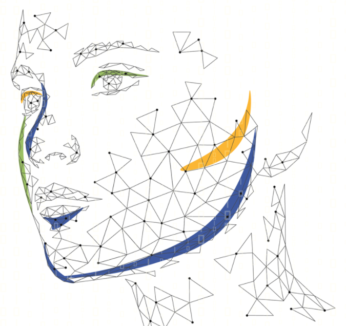

## 1. Overall introduction

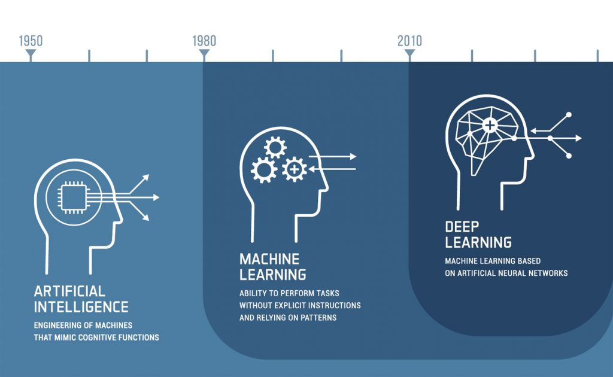

Deep learning is a sub-field of Machine learning. But in 5 years recently, Deep learning has have lots of achievements by the two main reasons:

- Data explosion
- Hardware development

## 2. Neural network

Inspired by human brain, neural network is an architecture where lots of neurons connected together.

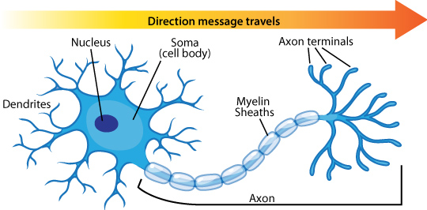

Neurons in neural network are connected to create layers. There are three types:

- `Input layer`
- `Hidden layer`
- `Output layer`

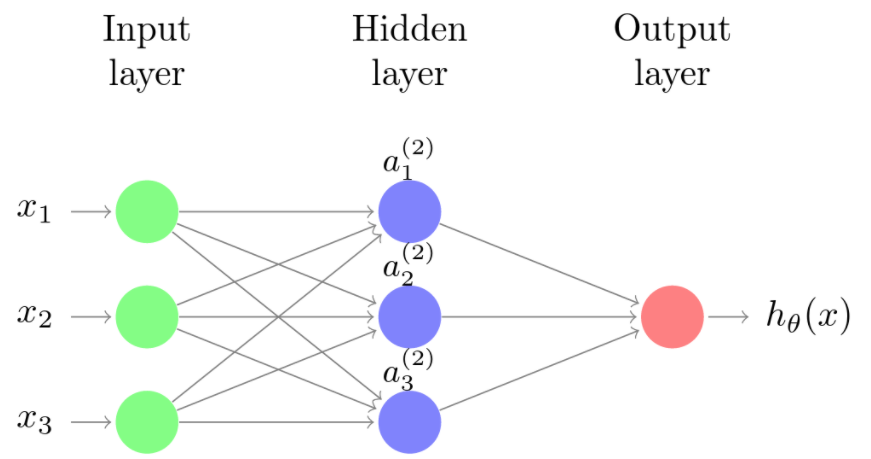

### 2.1. Layers

In simple neural network, there are some types of layers: linear layer, different function in activation layer, dropout layer ...

#### Linear layer

Each neuron in linear layer can be calculate as:  
${z}^{(l)}_{i} = \sum_{l(l-1)}^{j=1} {a}^{(l−1)}_{j} ∗ {w}^{(l)}_{ji} + {b}^{(l)}_{i}$  
${a}^{(l)}_{i} = \sigma({z}^{(l)}_{i})$  
where:  
${w}^{m}_{n}$ is the n-th weight of linear operator in layer m-th.  
${b}^{m}_{n}$ is the n-th bias of linear operator in layer m-th.  
${z}^{m}_{n}$ is the n-th results of linear operator in layer m-th.  
${a}^{m}_{n}$ is the output of neuron n-th in layer m-th.

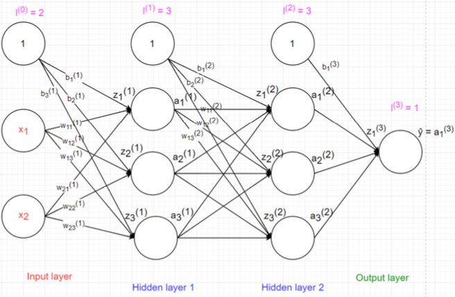

#### Activation layer: ReLU and Leaky ReLU

ReLU stands for Rectified-Linear Unit is an activation function.

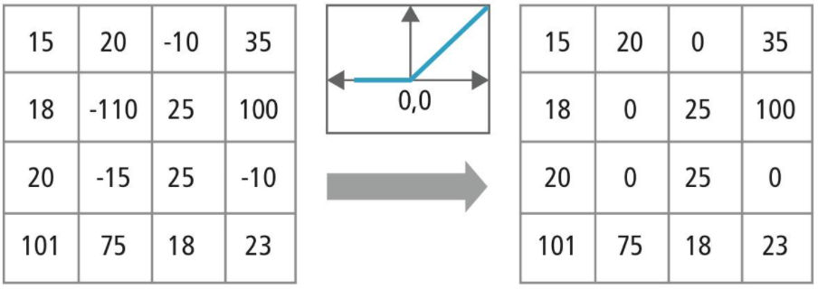

One problem of ReLU is `vanishing gradient` and Leaky ReLU will solve this problem.

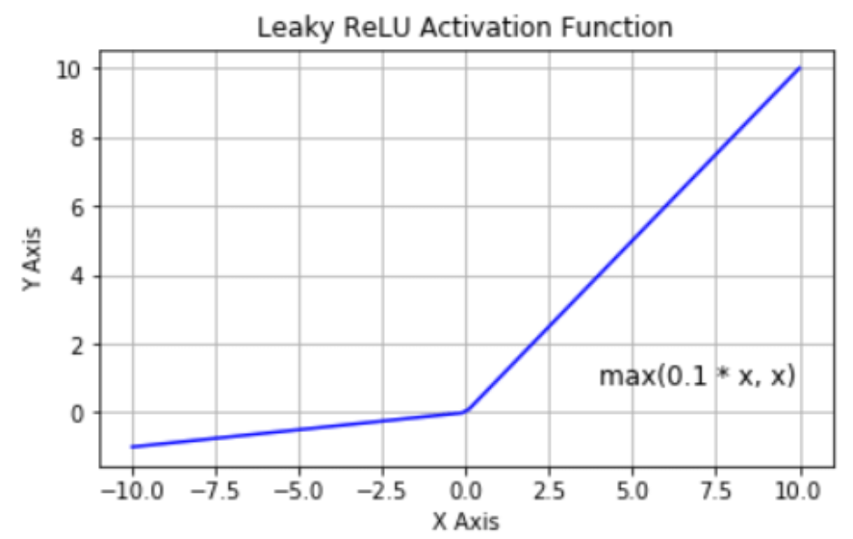

ReLU and Leaky ReLu is used in hidden layers in a neural network.

#### Activation layer: Sigmoid, Softmax and Tanh

Sigmoid, Softmax and Tanh are activation function for classification problem, and they are used in the last layer of a neural network.  
Sigmoid function get any input value and give an output in range from 0 to 1. This value can be understand as probability.

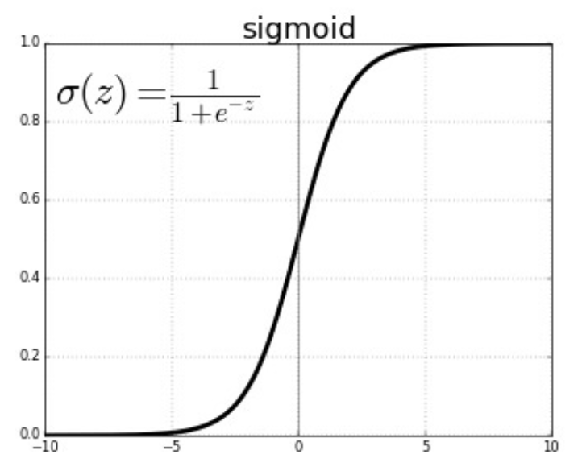

Like Sigmoid, Softmax give an output in range from 0 to 1. But, while Sigmoid is applied for each neuron in a network independently, Softmax is applied for all neurons in a network.

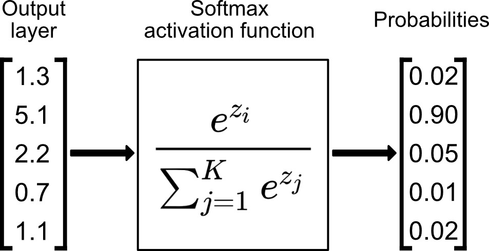

The difference between Sigmoid and Tanh is range of output value. Tanh give an output in range from -1 to 1.

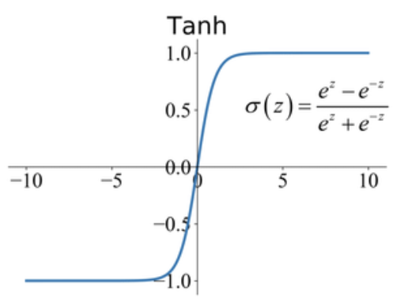

#### Dropout layer

Dropout layer randomly drop some weights in our network to prevent overfit problem.

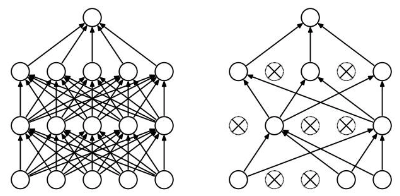

### 2.2. Model feedforward

From the input of neural network, we calculate the output value of each neuron each layer until we get the output of neural network. This process called `model feedforward`.

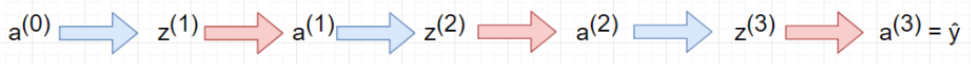

The output of neural network is call `prediction` or $\hat{y}$.

### 2.3. Loss function

After calculate the `prediction` of a neural network, we can use this `prediction` in `loss fucntion`. `loss fucntion` calculate the difference between the output of model and the groundtruth value. The smaller difference, the better model evaluation. The bigger difference, the worse model evaluation.  
Total loss value of all samples in the training set is called `cost value`.  
There are several types of loss function for each problem: `binary cross-entropy` or `categorical cross-entropy` for classification problem, `squared error` or `absolute error` for regression problem ...

#### Binary cross-entropy

#### Categorical cross-entropy

#### Squared error

#### Absolute error

### 2.4. Model backpropagation

### 2.5. Optimizer

## 3. Some other definitions

### 3.1. Underfitting model and overfitting model

## 4. Simple implementation

### 4.1. Problem

The dataset is shared by [House prices prediction](https://www.kaggle.com/c/house-prices-advanced-regression-techniques) from Kaggle.  
The dataset contains some features about a house and our mission is to predict the house price base on the features.

#### Data fields

1. `SalePrice`: the property's sale price in dollars. This is the target variable that you're trying to predict.
2. `MSSubClass`: The building class
3. `MSZoning`: The general zoning classification
4. `LotFrontage`: Linear feet of street connected to property
5. `LotArea`: Lot size in square feet
6. `Street`: Type of road access
7. `Alley`: Type of alley access
8. `LotShape`: General shape of property
9. `LandContour`: Flatness of the property
10. `Utilities`: Type of utilities available
11. `LotConfig`: Lot configuration
12. `LandSlope`: Slope of property
13. `Neighborhood`: Physical locations within Ames city limits
14. `Condition1`: Proximity to main road or railroad
15. `Condition2`: Proximity to main road or railroad (if a second is present)
16. `BldgType`: Type of dwelling
17. `HouseStyle`: Style of dwelling
18. `OverallQual`: Overall material and finish quality
19. `OverallCond`: Overall condition rating
20. `YearBuilt`: Original construction date
21. `YearRemodAdd`: Remodel date
22. `RoofStyle`: Type of roof
23. `RoofMatl`: Roof material
24. `Exterior1st`: Exterior covering on house
25. `Exterior2nd`: Exterior covering on house (if more than one material)
26. `MasVnrType`: Masonry veneer type
27. `MasVnrArea`: Masonry veneer area in square feet
28. `ExterQual`: Exterior material quality
29. `ExterCond`: Present condition of the material on the exterior
30. `Foundation`: Type of foundation
31. `BsmtQual`: Height of the basement
32. `BsmtCond`: General condition of the basement
33. `BsmtExposure`: Walkout or garden level basement walls
34. `BsmtFinType1`: Quality of basement finished area
35. `BsmtFinSF1`: Type 1 finished square feet
36. `BsmtFinType2`: Quality of second finished area (if present)
37. `BsmtFinSF2`: Type 2 finished square feet
38. `BsmtUnfSF`: Unfinished square feet of basement area
39. `TotalBsmtSF`: Total square feet of basement area
40. `Heating`: Type of heating
41. `HeatingQC`: Heating quality and condition
42. `CentralAir`: Central air conditioning
43. `Electrical`: Electrical system
44. `1stFlrSF`: First Floor square feet
45. `2ndFlrSF`: Second floor square feet
46. `LowQualFinSF`: Low quality finished square feet (all floors)
47. `GrLivArea`: Above grade (ground) living area square feet
48. `BsmtFullBath`: Basement full bathrooms
49. `BsmtHalfBath`: Basement half bathrooms
50. `FullBath`: Full bathrooms above grade
51. `HalfBath`: Half baths above grade
52. `Bedroom`: Number of bedrooms above basement level
53. `Kitchen`: Number of kitchens
54. `KitchenQual`: Kitchen quality
55. `TotRmsAbvGrd`: Total rooms above grade (does not include bathrooms)
56. `Functional`: Home functionality rating
57. `Fireplaces`: Number of fireplaces
58. `FireplaceQu`: Fireplace quality
59. `GarageType`: Garage location
60. `GarageYrBlt`: Year garage was built
61. `GarageFinish`: Interior finish of the garage
62. `GarageCars`: Size of garage in car capacity
63. `GarageArea`: Size of garage in square feet
64. `GarageQual`: Garage quality
65. `GarageCond`: Garage condition
66. `PavedDrive`: Paved driveway
67. `WoodDeckSF`: Wood deck area in square feet
68. `OpenPorchSF`: Open porch area in square feet
69. `EnclosedPorch`: Enclosed porch area in square feet
70. `3SsnPorch`: Three season porch area in square feet
71. `ScreenPorch`: Screen porch area in square feet
72. `PoolArea`: Pool area in square feet
73. `PoolQC`: Pool quality
74. `Fence`: Fence quality
75. `MiscFeature`: Miscellaneous feature not covered in other categories
76. `MiscVal`: Value of miscellaneous feature
77. `MoSold`: Month Sold
78. `YrSold`: Year Sold
79. `SaleType`: Type of sale
80. `SaleCondition`: Condition of sale

### 4.2. Solution

We use `keras` to preprocess data and build a simple neural network. `keras` is built on top of `tensorflow` and it contains consistent and simple APIs.  
First, we have to install `tensorflow` by running this command in jupyter notebook `!conda install -c anaconda tensorflow -y`.  
To install `keras`, we simply run `!conda install -c anaconda keras -y`.

```python
import os

import numpy as np
import pandas as pd
import seaborn as sns
from scipy.stats import skew
import matplotlib.pyplot as plt
from sklearn.preprocessing import StandardScaler
from keras.layers import Dense
from keras.optimizers import Adam
from keras.models import Sequential
from keras.losses import MeanSquaredError
from keras.callbacks import ModelCheckpoint, ReduceLROnPlateau, TensorBoard

sns.set()
```

#### Prepare data

```python
df = pd.read_csv('../data/house_prices_dataset/train.csv')
df = df.drop(columns=['Id'])
df
```

|  | MSSubClass | MSZoning | LotFrontage | LotArea | Street | Alley | LotShape | LandContour | Utilities | LotConfig | ... | PoolArea | PoolQC | Fence | MiscFeature | MiscVal | MoSold | YrSold | SaleType | SaleCondition | SalePrice |
| --- | --- | --- | --- | --- | --- | --- | --- | --- | --- | --- | --- | --- | --- | --- | --- | --- | --- | --- | --- | --- | --- |
| 0 | 60 | RL | 65.0 | 8450 | Pave | NaN | Reg | Lvl | AllPub | Inside | ... | 0 | NaN | NaN | NaN | 0 | 2 | 2008 | WD | Normal | 208500 |
| 1 | 20 | RL | 80.0 | 9600 | Pave | NaN | Reg | Lvl | AllPub | FR2 | ... | 0 | NaN | NaN | NaN | 0 | 5 | 2007 | WD | Normal | 181500 |
| 2 | 60 | RL | 68.0 | 11250 | Pave | NaN | IR1 | Lvl | AllPub | Inside | ... | 0 | NaN | NaN | NaN | 0 | 9 | 2008 | WD | Normal | 223500 |
| 3 | 70 | RL | 60.0 | 9550 | Pave | NaN | IR1 | Lvl | AllPub | Corner | ... | 0 | NaN | NaN | NaN | 0 | 2 | 2006 | WD | Abnorml | 140000 |
| 4 | 60 | RL | 84.0 | 14260 | Pave | NaN | IR1 | Lvl | AllPub | FR2 | ... | 0 | NaN | NaN | NaN | 0 | 12 | 2008 | WD | Normal | 250000 |
| ... | ... | ... | ... | ... | ... | ... | ... | ... | ... | ... | ... | ... | ... | ... | ... | ... | ... | ... | ... | ... | ... |
| 1455 | 60 | RL | 62.0 | 7917 | Pave | NaN | Reg | Lvl | AllPub | Inside | ... | 0 | NaN | NaN | NaN | 0 | 8 | 2007 | WD | Normal | 175000 |
| 1456 | 20 | RL | 85.0 | 13175 | Pave | NaN | Reg | Lvl | AllPub | Inside | ... | 0 | NaN | MnPrv | NaN | 0 | 2 | 2010 | WD | Normal | 210000 |
| 1457 | 70 | RL | 66.0 | 9042 | Pave | NaN | Reg | Lvl | AllPub | Inside | ... | 0 | NaN | GdPrv | Shed | 2500 | 5 | 2010 | WD | Normal | 266500 |
| 1458 | 20 | RL | 68.0 | 9717 | Pave | NaN | Reg | Lvl | AllPub | Inside | ... | 0 | NaN | NaN | NaN | 0 | 4 | 2010 | WD | Normal | 142125 |
| 1459 | 20 | RL | 75.0 | 9937 | Pave | NaN | Reg | Lvl | AllPub | Inside | ... | 0 | NaN | NaN | NaN | 0 | 6 | 2008 | WD | Normal | 147500 |

1460 rows × 80 columns

#### Preprocess skewed data

`y_train` distribution is skewd. So we will transform `y_train` to normal distribution by using `np.log1p`.

```python
# Get all numeric feature columns
numeric_col = df.dtypes[df.dtypes != "object"].index
```

```python
# Calculate the shewness and get index of columns which are shewed
skewness = df[numeric_col].apply(lambda x: skew(x.dropna()))
skewness = skewness[skewness > 0.75]
skewness_cols = skewness.index
skewness_cols
```

```
Index(['MSSubClass', 'LotFrontage', 'LotArea', 'MasVnrArea', 'BsmtFinSF1',
       'BsmtFinSF2', 'BsmtUnfSF', 'TotalBsmtSF', '1stFlrSF', '2ndFlrSF',
       'LowQualFinSF', 'GrLivArea', 'BsmtHalfBath', 'KitchenAbvGr',
       'WoodDeckSF', 'OpenPorchSF', 'EnclosedPorch', '3SsnPorch',
       'ScreenPorch', 'PoolArea', 'MiscVal', 'SalePrice'],
      dtype='object')
```

```python
def show_with_subplot(data, cols):
    subplot_n_cols = 5
    subplot_n_rows = int(len(cols) / subplot_n_cols) + 1

    plt.figure(figsize=(15,12))
    for idx, col in enumerate(cols):
        plt.subplot(subplot_n_rows, subplot_n_cols, idx+1)
        sns.histplot(x=col, data=data)

    plt.tight_layout()
    plt.show()
```

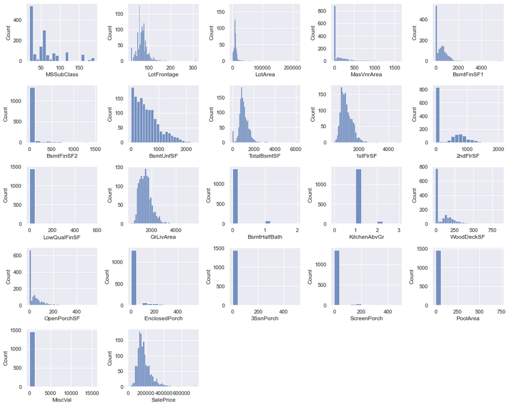

```python
show_with_subplot(df, skewness_cols)
```

```python
df[skewness_cols] = np.log1p(df[skewness_cols])
df
```

|  | MSSubClass | MSZoning | LotFrontage | LotArea | Street | Alley | LotShape | LandContour | Utilities | LotConfig | ... | PoolArea | PoolQC | Fence | MiscFeature | MiscVal | MoSold | YrSold | SaleType | SaleCondition | SalePrice |
| --- | --- | --- | --- | --- | --- | --- | --- | --- | --- | --- | --- | --- | --- | --- | --- | --- | --- | --- | --- | --- | --- |
| 0 | 4.110874 | RL | 4.189655 | 9.042040 | Pave | NaN | Reg | Lvl | AllPub | Inside | ... | 0.0 | NaN | NaN | NaN | 0.000000 | 2 | 2008 | WD | Normal | 12.247699 |
| 1 | 3.044522 | RL | 4.394449 | 9.169623 | Pave | NaN | Reg | Lvl | AllPub | FR2 | ... | 0.0 | NaN | NaN | NaN | 0.000000 | 5 | 2007 | WD | Normal | 12.109016 |
| 2 | 4.110874 | RL | 4.234107 | 9.328212 | Pave | NaN | IR1 | Lvl | AllPub | Inside | ... | 0.0 | NaN | NaN | NaN | 0.000000 | 9 | 2008 | WD | Normal | 12.317171 |
| 3 | 4.262680 | RL | 4.110874 | 9.164401 | Pave | NaN | IR1 | Lvl | AllPub | Corner | ... | 0.0 | NaN | NaN | NaN | 0.000000 | 2 | 2006 | WD | Abnorml | 11.849405 |
| 4 | 4.110874 | RL | 4.442651 | 9.565284 | Pave | NaN | IR1 | Lvl | AllPub | FR2 | ... | 0.0 | NaN | NaN | NaN | 0.000000 | 12 | 2008 | WD | Normal | 12.429220 |
| ... | ... | ... | ... | ... | ... | ... | ... | ... | ... | ... | ... | ... | ... | ... | ... | ... | ... | ... | ... | ... | ... |
| 1455 | 4.110874 | RL | 4.143135 | 8.976894 | Pave | NaN | Reg | Lvl | AllPub | Inside | ... | 0.0 | NaN | NaN | NaN | 0.000000 | 8 | 2007 | WD | Normal | 12.072547 |
| 1456 | 3.044522 | RL | 4.454347 | 9.486152 | Pave | NaN | Reg | Lvl | AllPub | Inside | ... | 0.0 | NaN | MnPrv | NaN | 0.000000 | 2 | 2010 | WD | Normal | 12.254868 |
| 1457 | 4.262680 | RL | 4.204693 | 9.109746 | Pave | NaN | Reg | Lvl | AllPub | Inside | ... | 0.0 | NaN | GdPrv | Shed | 7.824446 | 5 | 2010 | WD | Normal | 12.493133 |
| 1458 | 3.044522 | RL | 4.234107 | 9.181735 | Pave | NaN | Reg | Lvl | AllPub | Inside | ... | 0.0 | NaN | NaN | NaN | 0.000000 | 4 | 2010 | WD | Normal | 11.864469 |
| 1459 | 3.044522 | RL | 4.330733 | 9.204121 | Pave | NaN | Reg | Lvl | AllPub | Inside | ... | 0.0 | NaN | NaN | NaN | 0.000000 | 6 | 2008 | WD | Normal | 11.901590 |

1460 rows × 80 columns

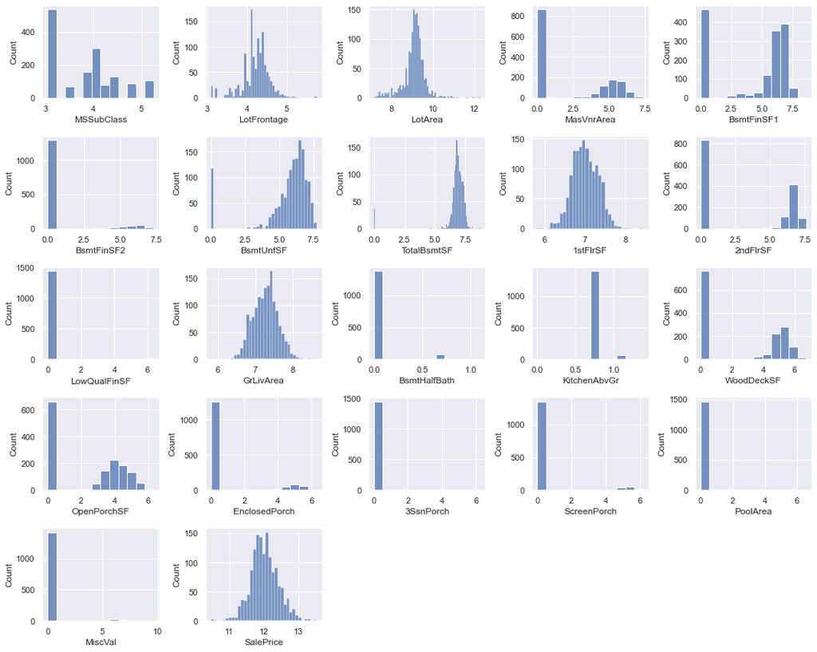

```python
show_with_subplot(df, skewness_cols)
```

#### Preprocess `nan` value data

```python
df = pd.get_dummies(df)
df
```

|  | MSSubClass | LotFrontage | LotArea | OverallQual | OverallCond | YearBuilt | YearRemodAdd | MasVnrArea | BsmtFinSF1 | BsmtFinSF2 | ... | SaleType_ConLw | SaleType_New | SaleType_Oth | SaleType_WD | SaleCondition_Abnorml | SaleCondition_AdjLand | SaleCondition_Alloca | SaleCondition_Family | SaleCondition_Normal | SaleCondition_Partial |
| --- | --- | --- | --- | --- | --- | --- | --- | --- | --- | --- | --- | --- | --- | --- | --- | --- | --- | --- | --- | --- | --- |
| 0 | 4.110874 | 4.189655 | 9.042040 | 7 | 5 | 2003 | 2003 | 5.283204 | 6.561031 | 0.000000 | ... | 0 | 0 | 0 | 1 | 0 | 0 | 0 | 0 | 1 | 0 |
| 1 | 3.044522 | 4.394449 | 9.169623 | 6 | 8 | 1976 | 1976 | 0.000000 | 6.886532 | 0.000000 | ... | 0 | 0 | 0 | 1 | 0 | 0 | 0 | 0 | 1 | 0 |
| 2 | 4.110874 | 4.234107 | 9.328212 | 7 | 5 | 2001 | 2002 | 5.093750 | 6.188264 | 0.000000 | ... | 0 | 0 | 0 | 1 | 0 | 0 | 0 | 0 | 1 | 0 |
| 3 | 4.262680 | 4.110874 | 9.164401 | 7 | 5 | 1915 | 1970 | 0.000000 | 5.379897 | 0.000000 | ... | 0 | 0 | 0 | 1 | 1 | 0 | 0 | 0 | 0 | 0 |
| 4 | 4.110874 | 4.442651 | 9.565284 | 8 | 5 | 2000 | 2000 | 5.860786 | 6.486161 | 0.000000 | ... | 0 | 0 | 0 | 1 | 0 | 0 | 0 | 0 | 1 | 0 |
| ... | ... | ... | ... | ... | ... | ... | ... | ... | ... | ... | ... | ... | ... | ... | ... | ... | ... | ... | ... | ... | ... |
| 1455 | 4.110874 | 4.143135 | 8.976894 | 6 | 5 | 1999 | 2000 | 0.000000 | 0.000000 | 0.000000 | ... | 0 | 0 | 0 | 1 | 0 | 0 | 0 | 0 | 1 | 0 |
| 1456 | 3.044522 | 4.454347 | 9.486152 | 6 | 6 | 1978 | 1988 | 4.787492 | 6.673298 | 5.099866 | ... | 0 | 0 | 0 | 1 | 0 | 0 | 0 | 0 | 1 | 0 |
| 1457 | 4.262680 | 4.204693 | 9.109746 | 7 | 9 | 1941 | 2006 | 0.000000 | 5.620401 | 0.000000 | ... | 0 | 0 | 0 | 1 | 0 | 0 | 0 | 0 | 1 | 0 |
| 1458 | 3.044522 | 4.234107 | 9.181735 | 5 | 6 | 1950 | 1996 | 0.000000 | 3.912023 | 6.937314 | ... | 0 | 0 | 0 | 1 | 0 | 0 | 0 | 0 | 1 | 0 |
| 1459 | 3.044522 | 4.330733 | 9.204121 | 5 | 6 | 1965 | 1965 | 0.000000 | 6.722630 | 5.673323 | ... | 0 | 0 | 0 | 1 | 0 | 0 | 0 | 0 | 1 | 0 |

1460 rows × 289 columns

```python
df = df.fillna(df.mean())
df
```

|  | MSSubClass | LotFrontage | LotArea | OverallQual | OverallCond | YearBuilt | YearRemodAdd | MasVnrArea | BsmtFinSF1 | BsmtFinSF2 | ... | SaleType_ConLw | SaleType_New | SaleType_Oth | SaleType_WD | SaleCondition_Abnorml | SaleCondition_AdjLand | SaleCondition_Alloca | SaleCondition_Family | SaleCondition_Normal | SaleCondition_Partial |
| --- | --- | --- | --- | --- | --- | --- | --- | --- | --- | --- | --- | --- | --- | --- | --- | --- | --- | --- | --- | --- | --- |
| 0 | 4.110874 | 4.189655 | 9.042040 | 7 | 5 | 2003 | 2003 | 5.283204 | 6.561031 | 0.000000 | ... | 0 | 0 | 0 | 1 | 0 | 0 | 0 | 0 | 1 | 0 |
| 1 | 3.044522 | 4.394449 | 9.169623 | 6 | 8 | 1976 | 1976 | 0.000000 | 6.886532 | 0.000000 | ... | 0 | 0 | 0 | 1 | 0 | 0 | 0 | 0 | 1 | 0 |
| 2 | 4.110874 | 4.234107 | 9.328212 | 7 | 5 | 2001 | 2002 | 5.093750 | 6.188264 | 0.000000 | ... | 0 | 0 | 0 | 1 | 0 | 0 | 0 | 0 | 1 | 0 |
| 3 | 4.262680 | 4.110874 | 9.164401 | 7 | 5 | 1915 | 1970 | 0.000000 | 5.379897 | 0.000000 | ... | 0 | 0 | 0 | 1 | 1 | 0 | 0 | 0 | 0 | 0 |
| 4 | 4.110874 | 4.442651 | 9.565284 | 8 | 5 | 2000 | 2000 | 5.860786 | 6.486161 | 0.000000 | ... | 0 | 0 | 0 | 1 | 0 | 0 | 0 | 0 | 1 | 0 |
| ... | ... | ... | ... | ... | ... | ... | ... | ... | ... | ... | ... | ... | ... | ... | ... | ... | ... | ... | ... | ... | ... |
| 1455 | 4.110874 | 4.143135 | 8.976894 | 6 | 5 | 1999 | 2000 | 0.000000 | 0.000000 | 0.000000 | ... | 0 | 0 | 0 | 1 | 0 | 0 | 0 | 0 | 1 | 0 |
| 1456 | 3.044522 | 4.454347 | 9.486152 | 6 | 6 | 1978 | 1988 | 4.787492 | 6.673298 | 5.099866 | ... | 0 | 0 | 0 | 1 | 0 | 0 | 0 | 0 | 1 | 0 |
| 1457 | 4.262680 | 4.204693 | 9.109746 | 7 | 9 | 1941 | 2006 | 0.000000 | 5.620401 | 0.000000 | ... | 0 | 0 | 0 | 1 | 0 | 0 | 0 | 0 | 1 | 0 |
| 1458 | 3.044522 | 4.234107 | 9.181735 | 5 | 6 | 1950 | 1996 | 0.000000 | 3.912023 | 6.937314 | ... | 0 | 0 | 0 | 1 | 0 | 0 | 0 | 0 | 1 | 0 |
| 1459 | 3.044522 | 4.330733 | 9.204121 | 5 | 6 | 1965 | 1965 | 0.000000 | 6.722630 | 5.673323 | ... | 0 | 0 | 0 | 1 | 0 | 0 | 0 | 0 | 1 | 0 |

1460 rows × 289 columns

#### Split data into train set and val set

```python
df
```

|  | MSSubClass | LotFrontage | LotArea | OverallQual | OverallCond | YearBuilt | YearRemodAdd | MasVnrArea | BsmtFinSF1 | BsmtFinSF2 | ... | SaleType_ConLw | SaleType_New | SaleType_Oth | SaleType_WD | SaleCondition_Abnorml | SaleCondition_AdjLand | SaleCondition_Alloca | SaleCondition_Family | SaleCondition_Normal | SaleCondition_Partial |
| --- | --- | --- | --- | --- | --- | --- | --- | --- | --- | --- | --- | --- | --- | --- | --- | --- | --- | --- | --- | --- | --- |
| 0 | 4.110874 | 4.189655 | 9.042040 | 7 | 5 | 2003 | 2003 | 5.283204 | 6.561031 | 0.000000 | ... | 0 | 0 | 0 | 1 | 0 | 0 | 0 | 0 | 1 | 0 |
| 1 | 3.044522 | 4.394449 | 9.169623 | 6 | 8 | 1976 | 1976 | 0.000000 | 6.886532 | 0.000000 | ... | 0 | 0 | 0 | 1 | 0 | 0 | 0 | 0 | 1 | 0 |
| 2 | 4.110874 | 4.234107 | 9.328212 | 7 | 5 | 2001 | 2002 | 5.093750 | 6.188264 | 0.000000 | ... | 0 | 0 | 0 | 1 | 0 | 0 | 0 | 0 | 1 | 0 |
| 3 | 4.262680 | 4.110874 | 9.164401 | 7 | 5 | 1915 | 1970 | 0.000000 | 5.379897 | 0.000000 | ... | 0 | 0 | 0 | 1 | 1 | 0 | 0 | 0 | 0 | 0 |
| 4 | 4.110874 | 4.442651 | 9.565284 | 8 | 5 | 2000 | 2000 | 5.860786 | 6.486161 | 0.000000 | ... | 0 | 0 | 0 | 1 | 0 | 0 | 0 | 0 | 1 | 0 |
| ... | ... | ... | ... | ... | ... | ... | ... | ... | ... | ... | ... | ... | ... | ... | ... | ... | ... | ... | ... | ... | ... |
| 1455 | 4.110874 | 4.143135 | 8.976894 | 6 | 5 | 1999 | 2000 | 0.000000 | 0.000000 | 0.000000 | ... | 0 | 0 | 0 | 1 | 0 | 0 | 0 | 0 | 1 | 0 |
| 1456 | 3.044522 | 4.454347 | 9.486152 | 6 | 6 | 1978 | 1988 | 4.787492 | 6.673298 | 5.099866 | ... | 0 | 0 | 0 | 1 | 0 | 0 | 0 | 0 | 1 | 0 |
| 1457 | 4.262680 | 4.204693 | 9.109746 | 7 | 9 | 1941 | 2006 | 0.000000 | 5.620401 | 0.000000 | ... | 0 | 0 | 0 | 1 | 0 | 0 | 0 | 0 | 1 | 0 |
| 1458 | 3.044522 | 4.234107 | 9.181735 | 5 | 6 | 1950 | 1996 | 0.000000 | 3.912023 | 6.937314 | ... | 0 | 0 | 0 | 1 | 0 | 0 | 0 | 0 | 1 | 0 |
| 1459 | 3.044522 | 4.330733 | 9.204121 | 5 | 6 | 1965 | 1965 | 0.000000 | 6.722630 | 5.673323 | ... | 0 | 0 | 0 | 1 | 0 | 0 | 0 | 0 | 1 | 0 |

1460 rows × 289 columns

```python
shuffle_df = df.sample(frac=1, random_state=1)
```

```python
shuffle_df
```

|  | MSSubClass | LotFrontage | LotArea | OverallQual | OverallCond | YearBuilt | YearRemodAdd | MasVnrArea | BsmtFinSF1 | BsmtFinSF2 | ... | SaleType_ConLw | SaleType_New | SaleType_Oth | SaleType_WD | SaleCondition_Abnorml | SaleCondition_AdjLand | SaleCondition_Alloca | SaleCondition_Family | SaleCondition_Normal | SaleCondition_Partial |
| --- | --- | --- | --- | --- | --- | --- | --- | --- | --- | --- | --- | --- | --- | --- | --- | --- | --- | --- | --- | --- | --- |
| 258 | 4.110874 | 4.394449 | 9.428351 | 7 | 5 | 2001 | 2001 | 5.153292 | 5.891644 | 0.000000 | ... | 0 | 0 | 0 | 1 | 0 | 0 | 0 | 0 | 1 | 0 |
| 267 | 4.330733 | 4.110874 | 9.036106 | 5 | 8 | 1939 | 1997 | 0.000000 | 5.937536 | 0.000000 | ... | 0 | 0 | 0 | 1 | 0 | 0 | 0 | 0 | 1 | 0 |
| 288 | 3.044522 | 4.207109 | 9.192176 | 5 | 5 | 1967 | 1967 | 3.465736 | 6.111467 | 0.000000 | ... | 0 | 0 | 0 | 1 | 0 | 0 | 0 | 0 | 1 | 0 |
| 649 | 5.198497 | 3.091042 | 7.568896 | 4 | 6 | 1970 | 1970 | 0.000000 | 4.882802 | 6.214608 | ... | 0 | 0 | 0 | 1 | 0 | 0 | 0 | 0 | 1 | 0 |
| 1233 | 3.044522 | 4.207109 | 9.405989 | 5 | 5 | 1959 | 1959 | 5.198497 | 6.908755 | 0.000000 | ... | 0 | 0 | 0 | 0 | 1 | 0 | 0 | 0 | 0 | 0 |
| ... | ... | ... | ... | ... | ... | ... | ... | ... | ... | ... | ... | ... | ... | ... | ... | ... | ... | ... | ... | ... | ... |
| 715 | 3.044522 | 4.369448 | 9.224342 | 6 | 5 | 1974 | 1974 | 5.164786 | 0.000000 | 0.000000 | ... | 0 | 0 | 0 | 1 | 0 | 0 | 0 | 0 | 1 | 0 |
| 905 | 3.044522 | 4.394449 | 9.202409 | 5 | 5 | 1954 | 1954 | 4.709530 | 5.872118 | 5.673323 | ... | 0 | 0 | 0 | 1 | 0 | 0 | 0 | 0 | 1 | 0 |
| 1096 | 4.262680 | 4.110874 | 8.836810 | 6 | 7 | 1914 | 2006 | 0.000000 | 0.000000 | 0.000000 | ... | 0 | 0 | 0 | 1 | 0 | 0 | 0 | 0 | 1 | 0 |
| 235 | 5.081404 | 3.091042 | 7.427144 | 6 | 3 | 1971 | 1971 | 6.405228 | 5.883322 | 0.000000 | ... | 0 | 0 | 0 | 1 | 0 | 0 | 0 | 0 | 1 | 0 |
| 1061 | 3.433987 | 4.795791 | 9.798183 | 3 | 4 | 1935 | 1950 | 0.000000 | 0.000000 | 0.000000 | ... | 0 | 0 | 0 | 0 | 0 | 0 | 0 | 0 | 1 | 0 |

1460 rows × 289 columns

```python
train_rate = 0.8
```

```python
train_df = shuffle_df.iloc[:int(len(shuffle_df) * train_rate)]
train_df
```

|  | MSSubClass | LotFrontage | LotArea | OverallQual | OverallCond | YearBuilt | YearRemodAdd | MasVnrArea | BsmtFinSF1 | BsmtFinSF2 | ... | SaleType_ConLw | SaleType_New | SaleType_Oth | SaleType_WD | SaleCondition_Abnorml | SaleCondition_AdjLand | SaleCondition_Alloca | SaleCondition_Family | SaleCondition_Normal | SaleCondition_Partial |
| --- | --- | --- | --- | --- | --- | --- | --- | --- | --- | --- | --- | --- | --- | --- | --- | --- | --- | --- | --- | --- | --- |
| 258 | 4.110874 | 4.394449 | 9.428351 | 7 | 5 | 2001 | 2001 | 5.153292 | 5.891644 | 0.000000 | ... | 0 | 0 | 0 | 1 | 0 | 0 | 0 | 0 | 1 | 0 |
| 267 | 4.330733 | 4.110874 | 9.036106 | 5 | 8 | 1939 | 1997 | 0.000000 | 5.937536 | 0.000000 | ... | 0 | 0 | 0 | 1 | 0 | 0 | 0 | 0 | 1 | 0 |
| 288 | 3.044522 | 4.207109 | 9.192176 | 5 | 5 | 1967 | 1967 | 3.465736 | 6.111467 | 0.000000 | ... | 0 | 0 | 0 | 1 | 0 | 0 | 0 | 0 | 1 | 0 |
| 649 | 5.198497 | 3.091042 | 7.568896 | 4 | 6 | 1970 | 1970 | 0.000000 | 4.882802 | 6.214608 | ... | 0 | 0 | 0 | 1 | 0 | 0 | 0 | 0 | 1 | 0 |
| 1233 | 3.044522 | 4.207109 | 9.405989 | 5 | 5 | 1959 | 1959 | 5.198497 | 6.908755 | 0.000000 | ... | 0 | 0 | 0 | 0 | 1 | 0 | 0 | 0 | 0 | 0 |
| ... | ... | ... | ... | ... | ... | ... | ... | ... | ... | ... | ... | ... | ... | ... | ... | ... | ... | ... | ... | ... | ... |
| 1317 | 4.795791 | 3.871201 | 8.350194 | 7 | 5 | 2006 | 2007 | 0.000000 | 0.000000 | 0.000000 | ... | 0 | 1 | 0 | 0 | 0 | 0 | 0 | 0 | 0 | 1 |
| 1107 | 4.110874 | 5.129899 | 10.054404 | 7 | 5 | 2006 | 2006 | 0.000000 | 0.000000 | 0.000000 | ... | 0 | 1 | 0 | 0 | 0 | 0 | 0 | 0 | 0 | 1 |
| 230 | 3.044522 | 4.304065 | 9.078065 | 6 | 6 | 1959 | 1959 | 5.398163 | 0.000000 | 0.000000 | ... | 0 | 0 | 0 | 1 | 0 | 0 | 0 | 0 | 1 | 0 |
| 652 | 4.110874 | 4.262680 | 9.076923 | 7 | 5 | 1996 | 1996 | 0.000000 | 0.000000 | 0.000000 | ... | 0 | 0 | 0 | 1 | 0 | 0 | 0 | 0 | 1 | 0 |
| 70 | 3.044522 | 4.564348 | 9.521641 | 7 | 6 | 1973 | 1973 | 7.017506 | 7.539559 | 0.000000 | ... | 0 | 0 | 0 | 1 | 0 | 0 | 0 | 0 | 1 | 0 |

1168 rows × 289 columns

```python
val_df = shuffle_df.iloc[int(len(shuffle_df) * train_rate):]
val_df
```

|  | MSSubClass | LotFrontage | LotArea | OverallQual | OverallCond | YearBuilt | YearRemodAdd | MasVnrArea | BsmtFinSF1 | BsmtFinSF2 | ... | SaleType_ConLw | SaleType_New | SaleType_Oth | SaleType_WD | SaleCondition_Abnorml | SaleCondition_AdjLand | SaleCondition_Alloca | SaleCondition_Family | SaleCondition_Normal | SaleCondition_Partial |
| --- | --- | --- | --- | --- | --- | --- | --- | --- | --- | --- | --- | --- | --- | --- | --- | --- | --- | --- | --- | --- | --- |
| 610 | 4.110874 | 4.207109 | 9.310276 | 9 | 5 | 2000 | 2000 | 5.323010 | 6.807935 | 0.000000 | ... | 0 | 0 | 0 | 1 | 0 | 0 | 0 | 0 | 1 | 0 |
| 1400 | 3.931826 | 3.931826 | 8.699681 | 6 | 7 | 1929 | 1950 | 0.000000 | 0.000000 | 0.000000 | ... | 0 | 0 | 0 | 1 | 0 | 0 | 0 | 0 | 1 | 0 |
| 1357 | 3.044522 | 4.207109 | 9.436519 | 5 | 6 | 1971 | 2008 | 0.000000 | 6.599870 | 0.000000 | ... | 0 | 0 | 0 | 1 | 0 | 0 | 0 | 0 | 1 | 0 |
| 1415 | 4.795791 | 3.951244 | 8.198639 | 7 | 5 | 2007 | 2007 | 4.875197 | 6.896694 | 0.000000 | ... | 0 | 0 | 0 | 1 | 0 | 0 | 0 | 0 | 1 | 0 |
| 410 | 3.044522 | 4.234107 | 9.166597 | 5 | 3 | 1958 | 1958 | 0.000000 | 0.000000 | 0.000000 | ... | 0 | 0 | 0 | 0 | 1 | 0 | 0 | 0 | 0 | 0 |
| ... | ... | ... | ... | ... | ... | ... | ... | ... | ... | ... | ... | ... | ... | ... | ... | ... | ... | ... | ... | ... | ... |
| 715 | 3.044522 | 4.369448 | 9.224342 | 6 | 5 | 1974 | 1974 | 5.164786 | 0.000000 | 0.000000 | ... | 0 | 0 | 0 | 1 | 0 | 0 | 0 | 0 | 1 | 0 |
| 905 | 3.044522 | 4.394449 | 9.202409 | 5 | 5 | 1954 | 1954 | 4.709530 | 5.872118 | 5.673323 | ... | 0 | 0 | 0 | 1 | 0 | 0 | 0 | 0 | 1 | 0 |
| 1096 | 4.262680 | 4.110874 | 8.836810 | 6 | 7 | 1914 | 2006 | 0.000000 | 0.000000 | 0.000000 | ... | 0 | 0 | 0 | 1 | 0 | 0 | 0 | 0 | 1 | 0 |
| 235 | 5.081404 | 3.091042 | 7.427144 | 6 | 3 | 1971 | 1971 | 6.405228 | 5.883322 | 0.000000 | ... | 0 | 0 | 0 | 1 | 0 | 0 | 0 | 0 | 1 | 0 |
| 1061 | 3.433987 | 4.795791 | 9.798183 | 3 | 4 | 1935 | 1950 | 0.000000 | 0.000000 | 0.000000 | ... | 0 | 0 | 0 | 0 | 0 | 0 | 0 | 0 | 1 | 0 |

292 rows × 289 columns

```python
x_train_df = train_df.drop(columns=['SalePrice'])
x_train_df
```

|  | MSSubClass | LotFrontage | LotArea | OverallQual | OverallCond | YearBuilt | YearRemodAdd | MasVnrArea | BsmtFinSF1 | BsmtFinSF2 | ... | SaleType_ConLw | SaleType_New | SaleType_Oth | SaleType_WD | SaleCondition_Abnorml | SaleCondition_AdjLand | SaleCondition_Alloca | SaleCondition_Family | SaleCondition_Normal | SaleCondition_Partial |
| --- | --- | --- | --- | --- | --- | --- | --- | --- | --- | --- | --- | --- | --- | --- | --- | --- | --- | --- | --- | --- | --- |
| 258 | 4.110874 | 4.394449 | 9.428351 | 7 | 5 | 2001 | 2001 | 5.153292 | 5.891644 | 0.000000 | ... | 0 | 0 | 0 | 1 | 0 | 0 | 0 | 0 | 1 | 0 |
| 267 | 4.330733 | 4.110874 | 9.036106 | 5 | 8 | 1939 | 1997 | 0.000000 | 5.937536 | 0.000000 | ... | 0 | 0 | 0 | 1 | 0 | 0 | 0 | 0 | 1 | 0 |
| 288 | 3.044522 | 4.207109 | 9.192176 | 5 | 5 | 1967 | 1967 | 3.465736 | 6.111467 | 0.000000 | ... | 0 | 0 | 0 | 1 | 0 | 0 | 0 | 0 | 1 | 0 |
| 649 | 5.198497 | 3.091042 | 7.568896 | 4 | 6 | 1970 | 1970 | 0.000000 | 4.882802 | 6.214608 | ... | 0 | 0 | 0 | 1 | 0 | 0 | 0 | 0 | 1 | 0 |
| 1233 | 3.044522 | 4.207109 | 9.405989 | 5 | 5 | 1959 | 1959 | 5.198497 | 6.908755 | 0.000000 | ... | 0 | 0 | 0 | 0 | 1 | 0 | 0 | 0 | 0 | 0 |
| ... | ... | ... | ... | ... | ... | ... | ... | ... | ... | ... | ... | ... | ... | ... | ... | ... | ... | ... | ... | ... | ... |
| 1317 | 4.795791 | 3.871201 | 8.350194 | 7 | 5 | 2006 | 2007 | 0.000000 | 0.000000 | 0.000000 | ... | 0 | 1 | 0 | 0 | 0 | 0 | 0 | 0 | 0 | 1 |
| 1107 | 4.110874 | 5.129899 | 10.054404 | 7 | 5 | 2006 | 2006 | 0.000000 | 0.000000 | 0.000000 | ... | 0 | 1 | 0 | 0 | 0 | 0 | 0 | 0 | 0 | 1 |
| 230 | 3.044522 | 4.304065 | 9.078065 | 6 | 6 | 1959 | 1959 | 5.398163 | 0.000000 | 0.000000 | ... | 0 | 0 | 0 | 1 | 0 | 0 | 0 | 0 | 1 | 0 |
| 652 | 4.110874 | 4.262680 | 9.076923 | 7 | 5 | 1996 | 1996 | 0.000000 | 0.000000 | 0.000000 | ... | 0 | 0 | 0 | 1 | 0 | 0 | 0 | 0 | 1 | 0 |
| 70 | 3.044522 | 4.564348 | 9.521641 | 7 | 6 | 1973 | 1973 | 7.017506 | 7.539559 | 0.000000 | ... | 0 | 0 | 0 | 1 | 0 | 0 | 0 | 0 | 1 | 0 |

1168 rows × 288 columns

```python
x_val_df = val_df.drop(columns=['SalePrice'])
x_val_df
```

|  | MSSubClass | LotFrontage | LotArea | OverallQual | OverallCond | YearBuilt | YearRemodAdd | MasVnrArea | BsmtFinSF1 | BsmtFinSF2 | ... | SaleType_ConLw | SaleType_New | SaleType_Oth | SaleType_WD | SaleCondition_Abnorml | SaleCondition_AdjLand | SaleCondition_Alloca | SaleCondition_Family | SaleCondition_Normal | SaleCondition_Partial |
| --- | --- | --- | --- | --- | --- | --- | --- | --- | --- | --- | --- | --- | --- | --- | --- | --- | --- | --- | --- | --- | --- |
| 610 | 4.110874 | 4.207109 | 9.310276 | 9 | 5 | 2000 | 2000 | 5.323010 | 6.807935 | 0.000000 | ... | 0 | 0 | 0 | 1 | 0 | 0 | 0 | 0 | 1 | 0 |
| 1400 | 3.931826 | 3.931826 | 8.699681 | 6 | 7 | 1929 | 1950 | 0.000000 | 0.000000 | 0.000000 | ... | 0 | 0 | 0 | 1 | 0 | 0 | 0 | 0 | 1 | 0 |
| 1357 | 3.044522 | 4.207109 | 9.436519 | 5 | 6 | 1971 | 2008 | 0.000000 | 6.599870 | 0.000000 | ... | 0 | 0 | 0 | 1 | 0 | 0 | 0 | 0 | 1 | 0 |
| 1415 | 4.795791 | 3.951244 | 8.198639 | 7 | 5 | 2007 | 2007 | 4.875197 | 6.896694 | 0.000000 | ... | 0 | 0 | 0 | 1 | 0 | 0 | 0 | 0 | 1 | 0 |
| 410 | 3.044522 | 4.234107 | 9.166597 | 5 | 3 | 1958 | 1958 | 0.000000 | 0.000000 | 0.000000 | ... | 0 | 0 | 0 | 0 | 1 | 0 | 0 | 0 | 0 | 0 |
| ... | ... | ... | ... | ... | ... | ... | ... | ... | ... | ... | ... | ... | ... | ... | ... | ... | ... | ... | ... | ... | ... |
| 715 | 3.044522 | 4.369448 | 9.224342 | 6 | 5 | 1974 | 1974 | 5.164786 | 0.000000 | 0.000000 | ... | 0 | 0 | 0 | 1 | 0 | 0 | 0 | 0 | 1 | 0 |
| 905 | 3.044522 | 4.394449 | 9.202409 | 5 | 5 | 1954 | 1954 | 4.709530 | 5.872118 | 5.673323 | ... | 0 | 0 | 0 | 1 | 0 | 0 | 0 | 0 | 1 | 0 |
| 1096 | 4.262680 | 4.110874 | 8.836810 | 6 | 7 | 1914 | 2006 | 0.000000 | 0.000000 | 0.000000 | ... | 0 | 0 | 0 | 1 | 0 | 0 | 0 | 0 | 1 | 0 |
| 235 | 5.081404 | 3.091042 | 7.427144 | 6 | 3 | 1971 | 1971 | 6.405228 | 5.883322 | 0.000000 | ... | 0 | 0 | 0 | 1 | 0 | 0 | 0 | 0 | 1 | 0 |
| 1061 | 3.433987 | 4.795791 | 9.798183 | 3 | 4 | 1935 | 1950 | 0.000000 | 0.000000 | 0.000000 | ... | 0 | 0 | 0 | 0 | 0 | 0 | 0 | 0 | 1 | 0 |

292 rows × 288 columns

```python
y_train_df = train_df['SalePrice']
y_train_df
```

```
258     12.352339
267     12.097936
288     11.711785
649     11.344519
1233    11.863589
          ...
1317    12.249616
1107    12.523530
230     11.904974
652     12.160034
70      12.404928
Name: SalePrice, Length: 1168, dtype: float64
```

```python
y_val_df = val_df['SalePrice']
y_val_df
```

```
610     12.653962
1400    11.695255
1357    11.917730
1415    12.077677
410     11.002117
          ...
715     12.013707
905     11.759793
1096    11.751950
235     11.402005
1061    11.302217
Name: SalePrice, Length: 292, dtype: float64
```

#### Transform data

```python
x_train = StandardScaler().fit_transform(x_train_df)
x_train
```

```
array([[ 0.41463693,  0.59673428,  0.62886363, ..., -0.13199092,
         0.48846721, -0.31919711],
       [ 0.73234998, -0.31043449, -0.14157367, ..., -0.13199092,
         0.48846721, -0.31919711],
       [-1.12631899, -0.0025746 ,  0.16497585, ..., -0.13199092,
         0.48846721, -0.31919711],
       ...,
       [-1.12631899,  0.30759203, -0.05915825, ..., -0.13199092,
         0.48846721, -0.31919711],
       [ 0.41463693,  0.17519906, -0.06140148, ..., -0.13199092,
         0.48846721, -0.31919711],
       [-1.12631899,  1.14024814,  0.81210256, ..., -0.13199092,
         0.48846721, -0.31919711]])
```

```python
x_train.shape
```

```
(1168, 288)
```

```python
y_train = y_train_df.values
y_train
```

```
array([12.35233947, 12.09793606, 11.71178452, ..., 11.90497431,
       12.16003394, 12.4049276 ])
```

```python
y_train.shape
```

```
(1168,)
```

```python
x_val = StandardScaler().fit_transform(x_val_df)
x_val
```

```
array([[ 0.46532857,  0.0100916 ,  0.34329959, ...,  0.        ,
         0.38091737, -0.24863262],
       [ 0.19886543, -0.85286659, -0.7706152 , ...,  0.        ,
         0.38091737, -0.24863262],
       [-1.12163681,  0.0100916 ,  0.57360628, ...,  0.        ,
         0.38091737, -0.24863262],
       ...,
       [ 0.6912493 , -0.29158615, -0.52045021, ...,  0.        ,
         0.38091737, -0.24863262],
       [ 1.90969135, -3.48855394, -3.0921189 , ...,  0.        ,
         0.38091737, -0.24863262],
       [-0.54202761,  1.85549086,  1.23339257, ...,  0.        ,
         0.38091737, -0.24863262]])
```

```python
x_val.shape
```

```
(292, 288)
```

```python
y_val = y_val_df.values
y_val
```

```
array([12.65396166, 11.69525536, 11.91773036, 12.07767662, 11.00211651,
       12.08391066, 11.91773036, 12.2185001 , 11.63071739, 11.77721864,
       12.51356102, 11.85652226, 12.09458786, 11.83501621, 12.27839796,
       12.38422302, 11.51293546, 11.29602489, 11.8167343 , 12.08954445,
       12.66033109, 11.44036552, 12.66033109, 12.17819258, 11.81303746,
       11.90497431, 12.66270921, 11.41145736, 11.92504174, 11.71178452,
       11.90159023, 12.15478461, 12.72486942, 11.75587949, 12.71640515,
       12.22588017, 11.96400745, 11.79056478, 12.69158354, 12.01370681,
       12.69158354, 13.22672519, 12.29225493, 12.12269647, 11.77529742,
       11.94406482, 12.34583894, 11.82408722, 12.29911207, 12.31268687,
       12.01461549, 11.75979336, 11.69525536, 11.56647571, 11.85652226,
       12.3327097 , 12.47801017, 11.98916586, 11.97939159, 12.09369311,
       12.4761036 , 12.06681633, 11.77529742, 11.87688084, 11.63515195,
       11.71178452, 12.39669714, 11.9117083 , 11.51293546, 11.77913617,
       12.47801017, 12.37792711, 11.60824474, 12.45293663, 11.91036512,
       12.15478461, 12.16785663, 12.27839796, 11.69108002, 11.79056478,
       12.23077014, 12.35978466, 12.25486757, 11.90497431, 11.84079653,
       12.15478461, 12.27839796, 12.06681633, 11.86446927, 11.76757544,
       12.22096618, 11.79434547, 11.85652226, 11.58896942, 12.35449696,
       11.4510607 , 11.94471437, 11.84142313, 12.37581964, 12.01370681,
       13.02132905, 11.69941333, 12.11176746, 12.13270056, 12.15478461,
       11.89136875, 12.10016198, 12.01370681, 11.73206903, 12.1034916 ,
       11.91639525, 11.97035664, 11.42410518, 12.75130259, 12.34148165,
       12.84792916, 12.19349893, 11.85652226, 11.84940484, 11.6526961 ,
       12.38839837, 12.0287446 , 11.51293546, 12.54254845, 12.15478461,
       11.88793824, 11.99535779, 12.17922033, 12.02719116, 11.96357424,
       11.84510995, 11.75587949, 12.37159132, 12.23709155, 12.52416631,
       11.60824474, 12.3194058 , 12.27134996, 11.87409728, 11.39640288,
       11.88104171, 12.07540002, 12.16598476, 11.94666052, 11.34924115,
       11.73206903, 11.61729449, 11.75587949, 11.91839724, 12.50618094,
       12.20607765, 11.68183245, 12.04942468, 11.68267668, 11.84869031,
       11.89819467, 12.93675402, 11.72804491, 12.69250619, 11.76369197,
       11.93819974, 11.28979441, 12.25961815, 11.88621856, 12.61818561,
       11.8706069 , 12.26434627, 12.33929587, 12.12811651, 11.83138647,
       12.3282947 , 11.90834697, 12.55293005, 12.55484041, 11.3621142 ,
       11.93164238, 12.34347093, 12.17561859, 11.91505836, 12.15478461,
       11.91505836, 12.13886924, 12.16525586, 11.69316987, 11.90497431,
       12.27373597, 11.49273296, 11.82012336, 12.34583894, 12.20857451,
       11.58525543, 11.62626308, 11.60824474, 11.96400745, 12.14950759,
       11.75195024, 11.77529742, 12.07254697, 11.6526961 , 12.13886924,
       12.49874599, 11.95118685, 12.19552218, 11.57590965, 11.59451467,
       12.07824496, 12.56024797, 12.37370772, 11.27721579, 11.80932691,
       11.77529742, 12.52198132, 11.69525536, 12.23077014, 11.99535779,
       11.71994776, 12.61818561, 11.95118685, 12.03172521, 12.67294952,
       12.83468397, 12.15478461, 11.27721579, 10.97679913, 12.35449696,
       11.72804491, 12.2356363 , 13.22956979, 12.2185001 , 11.72804491,
       12.45410781, 12.65035133, 11.83138647, 11.79056478, 11.19135563,
       11.68267668, 12.38839837, 12.14950759, 12.08099683, 12.0311298 ,
       12.12269647, 12.50540286, 12.27793274, 12.90634935, 11.86358938,
       11.84940484, 12.08069648, 12.27022515, 11.49273296, 11.84510995,
       11.28854365, 11.93819974, 11.60824474, 12.53537999, 11.88449592,
       12.46844076, 11.80560254, 10.8685875 , 11.90091204, 12.14153946,
       12.19096408, 12.73670384, 12.46844076, 12.14420256, 12.52634654,
       11.3621142 , 12.49087934, 12.11121786, 11.58989577, 11.11246282,
       12.03172521, 12.06105265, 12.4292202 , 12.4292202 , 12.06528067,
       11.80560254, 12.37581964, 12.32386013, 11.66993776, 12.69158354,
       12.2404789 , 11.98916586, 11.49273296, 11.91839724, 11.73607702,
       11.66565514, 11.80186425, 12.01370681, 11.75979336, 11.75195024,
       11.40200508, 11.30221678])
```

```python
y_val.shape
```

```
(292,)
```

#### Prepare configs

```python
n_units = 1
lr = 1e-1
lr_factor = 0.1
lr_patience = 2
lr_min = 1e-10
folder_path = 'dl_example'
train_batch_size = 512
val_batch_size = 512
shuffle_train_set = True
n_epoch = 100
```

#### Build model

```python
model = Sequential([
    Dense(units=n_units, input_dim=x_train.shape[1])
])
model.summary()
```

```
Model: "sequential"
_________________________________________________________________
Layer (type)                 Output Shape              Param #
=================================================================
dense (Dense)                (None, 1)                 289
=================================================================
Total params: 289
Trainable params: 289
Non-trainable params: 0
_________________________________________________________________
```

#### Init loss function

```python
mse_loss = MeanSquaredError()
```

#### Init optimizer

```python
adam_opt = Adam(learning_rate=lr)
```

#### Init callbacks

```python
reduce_lr = ReduceLROnPlateau(monitor='val_loss', factor=lr_factor, patience=lr_patience, min_lr=lr_min)
```

```python
os.system(f'rm -r {folder_path}')
os.mkdir(folder_path)
```

```python
checkpoint = ModelCheckpoint(os.path.join(folder_path, 'model/model_{epoch:02d}.h5'))
```

#### Train model

```python
model.compile(loss=mse_loss, optimizer=adam_opt)
```

```python
history = model.fit(
    x=x_train,
    y=y_train,
    batch_size=train_batch_size,
    epochs=n_epoch,
    validation_data=(x_val, y_val),
    shuffle=shuffle_train_set,
    validation_batch_size=val_batch_size,
    callbacks=[checkpoint, reduce_lr]
)
```

#### Evaluate trained model

```python
train_loss = history.history['loss']
train_loss
```

```
[157.13954162597656,
 145.027099609375,
 135.27310180664062,
 126.11068725585938,
 121.44197082519531,
 114.47634887695312,
 107.83616638183594,
 103.09391021728516,
 96.86814880371094,
 90.82422637939453,
 86.07937622070312,
 80.76152038574219,
 75.28633117675781,
 70.97566986083984,
 66.67718505859375,
 61.77204513549805,
 58.48868179321289,
 54.20167541503906,
 50.70722961425781,
 47.3735237121582,
 44.09020233154297,
 40.99404525756836,
 38.11845397949219,
 35.367698669433594,
 32.85734558105469,
 30.29807472229004,
 28.532651901245117,
 26.193384170532227,
 24.194744110107422,
 21.92430877685547,
 20.634836196899414,
 18.72858238220215,
 17.334339141845703,
 15.932506561279297,
 14.331480979919434,
 13.674275398254395,
 11.995590209960938,
 11.084261894226074,
 10.047094345092773,
 9.146013259887695,
```

[output cut: 45 more lines]

```
 0.038769353181123734,
 0.03470491245388985,
 0.03138897940516472,
 0.02902866341173649,
 0.027818700298666954,
 0.02383328229188919,
 0.02163282409310341,
 0.019808454439044,
 0.01852705329656601,
 0.017109334468841553,
 0.015786685049533844,
 0.015010012313723564,
 0.014134615659713745,
 0.013534164987504482,
 0.012695598416030407]
```

```python
val_loss = history.history['val_loss']
val_loss
```

```
[143.84048461914062,
 134.2782745361328,
 126.1808090209961,
 121.13579559326172,
 114.43988037109375,
 107.95457458496094,
 102.5948715209961,
 97.06143188476562,
 91.13485717773438,
 86.12529754638672,
 81.26022338867188,
 75.90538787841797,
 71.72990417480469,
 67.19351196289062,
 61.9704475402832,
 58.73081588745117,
 54.34111022949219,
 50.730873107910156,
 47.61592483520508,
 44.32390594482422,
 41.510501861572266,
 38.690887451171875,
 35.74016189575195,
 32.959632873535156,
 30.76230812072754,
 28.503328323364258,
 26.541561126708984,
 24.35089874267578,
 22.201488494873047,
 20.93359375,
 18.780162811279297,
 17.49915313720703,
 16.03910255432129,
 14.46986198425293,
 13.59504508972168,
 12.149079322814941,
 11.277910232543945,
 10.172259330749512,
 9.342525482177734,
 8.393126487731934,
```

[output cut: 45 more lines]

```
 0.06998179852962494,
 0.06612555682659149,
 0.06422191858291626,
 0.06459128856658936,
 0.06265649944543839,
 0.05987543612718582,
 0.058973293751478195,
 0.05861307308077812,
 0.05772145092487335,
 0.05541674792766571,
 0.05233198404312134,
 0.05088399723172188,
 0.051005493849515915,
 0.049928851425647736,
 0.04928849637508392]
```

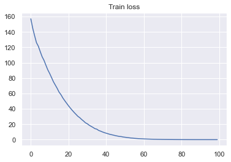

```python
sns.lineplot(x=range(n_epoch), y=train_loss)
plt.title('Train loss')
plt.show()
```

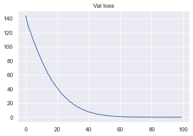

```python
sns.lineplot(x=range(n_epoch), y=val_loss)
plt.title('Val loss')
plt.show()
```

#### Use model to predict